# Predict Bike Sharing Demand with AutoGluon Template

## Project: Predict Bike Sharing Demand with AutoGluon

This notebook is a template with each step that you need to complete for the project.

Please fill in your code where there are explicit `?` markers in the notebook. You are welcome to add more cells and code as you see fit.

Once you have completed all the code implementations, please export your notebook as a HTML file so the reviews can view your code. Make sure you have all outputs correctly outputted.

`File-> Export Notebook As... -> Export Notebook as HTML`

There is a writeup to complete as well after all code implememtation is done. Please answer all questions and attach the necessary tables and charts. You can complete the writeup in either markdown or PDF.

Completing the code template and writeup template will cover all of the rubric points for this project.

The rubric contains "Stand Out Suggestions" for enhancing the project beyond the minimum requirements. The stand out suggestions are optional. If you decide to pursue the "stand out suggestions", you can include the code in this notebook and also discuss the results in the writeup file.

## Step 1: Create an account with Kaggle

### Create Kaggle Account and download API key

Below is example of steps to get the API username and key. Each student will have their own username and key.

1. Open account settings.

2. Scroll down to API and click Create New API Token.

3. Open up `kaggle.json` and use the username and key.


## Step 2: Download the Kaggle dataset using the kaggle python library

### Open up Sagemaker Studio and use starter template

1. Notebook should be using a `ml.t3.medium` instance (2 vCPU + 4 GiB)
2. Notebook should be using kernal: `Python 3 (MXNet 1.8 Python 3.7 CPU Optimized)`

### Install packages

```python
!pip install -U pip
!pip install -U setuptools wheel
!pip install -U "mxnet<2.0.0" bokeh==2.0.1
!pip install autogluon --no-cache-dir
# Without --no-cache-dir, smaller aws instances may have trouble installing
```

[output not shown]

[output cut: 46 more lines]

[output not shown]

### Setup Kaggle API Key

```python
# create the .kaggle directory and an empty kaggle.json file
!mkdir -p /root/.kaggle
!touch /root/.kaggle/kaggle.json
!chmod 600 /root/.kaggle/kaggle.json
```

```python
# Fill in your user name and key from creating the kaggle account and API token file
import json
# {"username":"raminanush","key":"570cbc67400daf1003fb36ca623da394"}
kaggle_username = "raminanush"
kaggle_key = "570cbc67400daf1003fb36ca623da394"

# Save API token the kaggle.json file
with open("/root/.kaggle/kaggle.json", "w") as f:
    f.write(json.dumps({"username": kaggle_username, "key": kaggle_key}))
```

### Download and explore dataset

### Go to the [bike sharing demand competition](https://www.kaggle.com/c/bike-sharing-demand) and agree to the terms

```python
# Download the dataset, it will be in a .zip file so you'll need to unzip it as well.
!kaggle competitions download -c bike-sharing-demand
# If you already downloaded it you can use the -o command to overwrite the file
# !apt-get install unzip

# !unzip -o bike-sharing-demand.zip
```

```
bike-sharing-demand.zip: Skipping, found more recently modified local copy (use --force to force download)
```

```python
!pip install ipywidgets
import pandas as pd
from autogluon.tabular import TabularPredictor
import ipywidgets as widgets
from ipywidgets import IntProgress
```

[output not shown]

```python
# Create the train dataset in pandas by reading the csv
# Set the parsing of the datetime column so you can use some of the `dt` features in pandas later

train = pd.read_csv('train.csv',parse_dates=['datetime'])
train.head()
```

|  | datetime | season | holiday | workingday | weather | temp | atemp | humidity | windspeed | casual | registered | count |
| --- | --- | --- | --- | --- | --- | --- | --- | --- | --- | --- | --- | --- |
| 0 | 2011-01-01 00:00:00 | 1 | 0 | 0 | 1 | 9.84 | 14.395 | 81 | 0.0 | 3 | 13 | 16 |
| 1 | 2011-01-01 01:00:00 | 1 | 0 | 0 | 1 | 9.02 | 13.635 | 80 | 0.0 | 8 | 32 | 40 |
| 2 | 2011-01-01 02:00:00 | 1 | 0 | 0 | 1 | 9.02 | 13.635 | 80 | 0.0 | 5 | 27 | 32 |
| 3 | 2011-01-01 03:00:00 | 1 | 0 | 0 | 1 | 9.84 | 14.395 | 75 | 0.0 | 3 | 10 | 13 |
| 4 | 2011-01-01 04:00:00 | 1 | 0 | 0 | 1 | 9.84 | 14.395 | 75 | 0.0 | 0 | 1 | 1 |

```python
# Simple output of the train dataset to view some of the min/max/varition of the dataset features.
train.describe()
```

|  | season | holiday | workingday | weather | temp | atemp | humidity | windspeed | casual | registered | count |
| --- | --- | --- | --- | --- | --- | --- | --- | --- | --- | --- | --- |
| count | 10886.000000 | 10886.000000 | 10886.000000 | 10886.000000 | 10886.00000 | 10886.000000 | 10886.000000 | 10886.000000 | 10886.000000 | 10886.000000 | 10886.000000 |
| mean | 2.506614 | 0.028569 | 0.680875 | 1.418427 | 20.23086 | 23.655084 | 61.886460 | 12.799395 | 36.021955 | 155.552177 | 191.574132 |
| std | 1.116174 | 0.166599 | 0.466159 | 0.633839 | 7.79159 | 8.474601 | 19.245033 | 8.164537 | 49.960477 | 151.039033 | 181.144454 |
| min | 1.000000 | 0.000000 | 0.000000 | 1.000000 | 0.82000 | 0.760000 | 0.000000 | 0.000000 | 0.000000 | 0.000000 | 1.000000 |
| 25% | 2.000000 | 0.000000 | 0.000000 | 1.000000 | 13.94000 | 16.665000 | 47.000000 | 7.001500 | 4.000000 | 36.000000 | 42.000000 |
| 50% | 3.000000 | 0.000000 | 1.000000 | 1.000000 | 20.50000 | 24.240000 | 62.000000 | 12.998000 | 17.000000 | 118.000000 | 145.000000 |
| 75% | 4.000000 | 0.000000 | 1.000000 | 2.000000 | 26.24000 | 31.060000 | 77.000000 | 16.997900 | 49.000000 | 222.000000 | 284.000000 |
| max | 4.000000 | 1.000000 | 1.000000 | 4.000000 | 41.00000 | 45.455000 | 100.000000 | 56.996900 | 367.000000 | 886.000000 | 977.000000 |

```python
# Create the test pandas dataframe in pandas by reading the csv, remember to parse the datetime!
test = pd.read_csv('test.csv',parse_dates=['datetime'])
test.head()
```

|  | datetime | season | holiday | workingday | weather | temp | atemp | humidity | windspeed |
| --- | --- | --- | --- | --- | --- | --- | --- | --- | --- |
| 0 | 2011-01-20 00:00:00 | 1 | 0 | 1 | 1 | 10.66 | 11.365 | 56 | 26.0027 |
| 1 | 2011-01-20 01:00:00 | 1 | 0 | 1 | 1 | 10.66 | 13.635 | 56 | 0.0000 |
| 2 | 2011-01-20 02:00:00 | 1 | 0 | 1 | 1 | 10.66 | 13.635 | 56 | 0.0000 |
| 3 | 2011-01-20 03:00:00 | 1 | 0 | 1 | 1 | 10.66 | 12.880 | 56 | 11.0014 |
| 4 | 2011-01-20 04:00:00 | 1 | 0 | 1 | 1 | 10.66 | 12.880 | 56 | 11.0014 |

```python
# Same thing as train and test dataset
submission = pd.read_csv('sampleSubmission.csv',parse_dates=['datetime'])
submission.head()
```

|  | datetime | count |
| --- | --- | --- |
| 0 | 2011-01-20 00:00:00 | 0 |
| 1 | 2011-01-20 01:00:00 | 0 |
| 2 | 2011-01-20 02:00:00 | 0 |
| 3 | 2011-01-20 03:00:00 | 0 |
| 4 | 2011-01-20 04:00:00 | 0 |

## Step 3: Train a model using AutoGluon’s Tabular Prediction

Requirements:

- We are predicting `count`, so it is the label we are setting.
- Ignore `casual` and `registered` columns as they are also not present in the test dataset.
- Use the `root_mean_squared_error` as the metric to use for evaluation.
- Set a time limit of 10 minutes (600 seconds).
- Use the preset `best_quality` to focus on creating the best model.

```python
train = train.drop(['casual','registered'],axis=1)
# # test = test.drop(['casual','registered'],axis=1)
# problem_type="regression", eval_metric="r2"
```

```python
predictor = TabularPredictor(label="count",eval_metric = 'root_mean_squared_error',problem_type="regression").fit(
    train_data=train, time_limit=600, presets="best_quality"
)
```

```
No path specified. Models will be saved in: "AutogluonModels/ag-20220902_022439/"
Presets specified: ['best_quality']
Beginning AutoGluon training ... Time limit = 600s
AutoGluon will save models to "AutogluonModels/ag-20220902_022439/"
AutoGluon Version:  0.3.1
Train Data Rows:    10886
Train Data Columns: 9
Preprocessing data ...
Using Feature Generators to preprocess the data ...
Fitting AutoMLPipelineFeatureGenerator...
	Available Memory:                    3088.58 MB
	Train Data (Original)  Memory Usage: 0.78 MB (0.0% of available memory)
	Inferring data type of each feature based on column values. Set feature_metadata_in to manually specify special dtypes of the features.
	Stage 1 Generators:
		Fitting AsTypeFeatureGenerator...
			Note: Converting 2 features to boolean dtype as they only contain 2 unique values.
	Stage 2 Generators:
		Fitting FillNaFeatureGenerator...
	Stage 3 Generators:
		Fitting IdentityFeatureGenerator...
		Fitting DatetimeFeatureGenerator...
	Stage 4 Generators:
		Fitting DropUniqueFeatureGenerator...
	Types of features in original data (raw dtype, special dtypes):
		('datetime', []) : 1 | ['datetime']
		('float', [])    : 3 | ['temp', 'atemp', 'windspeed']
		('int', [])      : 5 | ['season', 'holiday', 'workingday', 'weather', 'humidity']
	Types of features in processed data (raw dtype, special dtypes):
		('float', [])                : 3 | ['temp', 'atemp', 'windspeed']
		('int', [])                  : 3 | ['season', 'weather', 'humidity']
		('int', ['bool'])            : 2 | ['holiday', 'workingday']
		('int', ['datetime_as_int']) : 1 | ['datetime']
	0.1s = Fit runtime
	9 features in original data used to generate 9 features in processed data.
	Train Data (Processed) Memory Usage: 0.63 MB (0.0% of available memory)
Data preprocessing and feature engineering runtime = 0.18s ...
AutoGluon will gauge predictive performance using evaluation metric: 'root_mean_squared_error'
	To change this, specify the eval_metric argument of fit()
AutoGluon will fit 2 stack levels (L1 to L2) ...
Fitting 11 L1 models ...
Fitting model: KNeighborsUnif_BAG_L1 ... Training model for up to 399.78s of the 599.82s of remaining time.
	-160.4131	 = Validation score   (root_mean_squared_error)
	0.03s	 = Training   runtime
	0.1s	 = Validation runtime
Fitting model: KNeighborsDist_BAG_L1 ... Training model for up to 399.38s of the 599.42s of remaining time.
	-169.5521	 = Validation score   (root_mean_squared_error)
	0.02s	 = Training   runtime
	0.1s	 = Validation runtime
Fitting model: LightGBMXT_BAG_L1 ... Training model for up to 399.02s of the 599.06s of remaining time.
```

```
[1000]	train_set's rmse: 123.806	valid_set's rmse: 134.369
[2000]	train_set's rmse: 117.412	valid_set's rmse: 133.705
```

```
[1000]	train_set's rmse: 123.42	valid_set's rmse: 141.5
```

```
[1000]	train_set's rmse: 125.097	valid_set's rmse: 128.797
[2000]	train_set's rmse: 119.003	valid_set's rmse: 127.909
[3000]	train_set's rmse: 114.63	valid_set's rmse: 127.431
[4000]	train_set's rmse: 111.295	valid_set's rmse: 126.943
[5000]	train_set's rmse: 108.576	valid_set's rmse: 126.844
[6000]	train_set's rmse: 106.085	valid_set's rmse: 126.71
```

```
[1000]	train_set's rmse: 124.131	valid_set's rmse: 138.303
[2000]	train_set's rmse: 117.833	valid_set's rmse: 137.535
```

```
[1000]	train_set's rmse: 124.871	valid_set's rmse: 128.052
[2000]	train_set's rmse: 118.547	valid_set's rmse: 127.003
[3000]	train_set's rmse: 114.124	valid_set's rmse: 126.834
[4000]	train_set's rmse: 110.645	valid_set's rmse: 126.694
```

```
[1000]	train_set's rmse: 124.654	valid_set's rmse: 135.095
[2000]	train_set's rmse: 118.764	valid_set's rmse: 133.849
[3000]	train_set's rmse: 114.615	valid_set's rmse: 133.509
[4000]	train_set's rmse: 111.249	valid_set's rmse: 133.472
[5000]	train_set's rmse: 108.455	valid_set's rmse: 133.281
```

```
[1000]	train_set's rmse: 124.01	valid_set's rmse: 139.355
[2000]	train_set's rmse: 117.819	valid_set's rmse: 138.312
[3000]	train_set's rmse: 113.4	valid_set's rmse: 137.886
[4000]	train_set's rmse: 110.032	valid_set's rmse: 137.758
```

```
[1000]	train_set's rmse: 124.47	valid_set's rmse: 135.412
```

```
[1000]	train_set's rmse: 124.18	valid_set's rmse: 137.579
[2000]	train_set's rmse: 117.782	valid_set's rmse: 136.664
[3000]	train_set's rmse: 113.447	valid_set's rmse: 136.246
[4000]	train_set's rmse: 109.982	valid_set's rmse: 136.227
```

```
[1000]	train_set's rmse: 124.641	valid_set's rmse: 132.484
```

```
	-134.0883	 = Validation score   (root_mean_squared_error)
	47.3s	 = Training   runtime
	2.35s	 = Validation runtime
Fitting model: LightGBM_BAG_L1 ... Training model for up to 343.42s of the 543.46s of remaining time.
```

```
[1000]	train_set's rmse: 96.0217	valid_set's rmse: 123.249
```

```
[1000]	train_set's rmse: 94.7479	valid_set's rmse: 135.635
```

```
[1000]	train_set's rmse: 95.3055	valid_set's rmse: 132.087
```

```
[1000]	train_set's rmse: 95.1635	valid_set's rmse: 131.521
```

[output not shown]

[output cut: 176 more lines]

[output not shown]

### Review AutoGluon's training run with ranking of models that did the best.

```python
predictor.fit_summary()
```

```
*** Summary of fit() ***
Estimated performance of each model:
                     model   score_val  pred_time_val    fit_time  pred_time_val_marginal  fit_time_marginal  stack_level  can_infer  fit_order
0      WeightedEnsemble_L3 -115.741562       8.289289  528.352446                0.000948           0.450897            3       True         18
1        LightGBMXT_BAG_L2 -116.199013       6.061216  373.063164                0.191744           9.760366            2       True         11
2          CatBoost_BAG_L2 -116.500906       5.902725  386.923529                0.033253          23.620731            2       True         14
3          LightGBM_BAG_L2 -116.935509       5.938556  369.557686                0.069084           6.254887            2       True         12
4           XGBoost_BAG_L2 -117.360672       5.946574  378.293693                0.077101          14.990894            2       True         16
5     ExtraTreesMSE_BAG_L2 -117.591666       6.343735  369.756727                0.474262           6.453928            2       True         15
6      WeightedEnsemble_L2 -118.414460       2.054209  229.061213                0.000885           0.562428            2       True         10
7   RandomForestMSE_BAG_L1 -118.456660       0.388729    7.186204                0.388729           7.186204            1       True          5
8   RandomForestMSE_BAG_L2 -119.404690       6.342523  391.500049                0.473051          28.197251            2       True         13
9    NeuralNetMXNet_BAG_L2 -119.800953       7.442897  466.820742                1.573424         103.517944            2       True         17
10    ExtraTreesMSE_BAG_L1 -128.733445       0.553658    3.641664                0.553658           3.641664            1       True          7
11         LightGBM_BAG_L1 -132.286410       0.510406   12.980740                0.510406          12.980740            1       True          4
12          XGBoost_BAG_L1 -132.308522       0.145236   14.540817                0.145236          14.540817            1       True          8
13         CatBoost_BAG_L1 -132.349692       0.045406   56.292737                0.045406          56.292737            1       True          6
14       LightGBMXT_BAG_L1 -134.088334       2.353694   47.298060                2.353694          47.298060            1       True          3
15   NeuralNetMXNet_BAG_L1 -141.916597       1.664595  221.312581                1.664595         221.312581            1       True          9
16   KNeighborsUnif_BAG_L1 -160.413078       0.103273    0.027609                0.103273           0.027609            1       True          1
17   KNeighborsDist_BAG_L1 -169.552096       0.104477    0.022387                0.104477           0.022387            1       True          2
Number of models trained: 18
Types of models trained:
{'StackerEnsembleModel_LGB', 'StackerEnsembleModel_XGBoost', 'StackerEnsembleModel_RF', 'StackerEnsembleModel_CatBoost', 'StackerEnsembleModel_XT', 'WeightedEnsembleModel', 'StackerEnsembleModel_KNN', 'StackerEnsembleModel_TabularNeuralNet'}
Bagging used: True  (with 10 folds)
Multi-layer stack-ensembling used: True  (with 3 levels)
Feature Metadata (Processed):
(raw dtype, special dtypes):
('float', [])                : 3 | ['temp', 'atemp', 'windspeed']
('int', [])                  : 3 | ['season', 'weather', 'humidity']
('int', ['bool'])            : 2 | ['holiday', 'workingday']
('int', ['datetime_as_int']) : 1 | ['datetime']
Plot summary of models saved to file: AutogluonModels/ag-20220902_022439/SummaryOfModels.html
*** End of fit() summary ***
```

[output not shown]

[output cut: 175 more lines]

```
 3          12
 4          16
 5          15
 6          10
 7           5
 8          13
 9          17
 10          7
 11          4
 12          8
 13          6
 14          3
 15          9
 16          1
 17          2  }
```

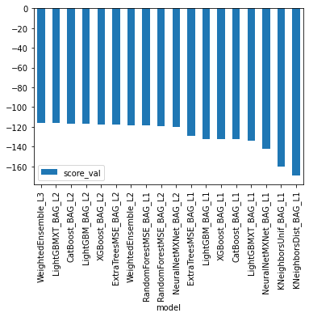

```python
from matplotlib.pylab import plt
fig = plt.figure()
predictor.leaderboard(silent=True).plot(kind="bar", x="model", y="score_val")
plt.savefig('img/raw_training_scores.png', dpi=300, bbox_inches='tight')
plt.show()
```

### Create predictions from test dataset

```python
predictions = predictor.predict(test)
predictions.head()
```

```
0     95.156311
1     89.293633
2     89.293625
3    102.843201
4    102.851944
Name: count, dtype: float32
```

```python
performance1 = predictor.evaluate(train)
```

```
Evaluation: root_mean_squared_error on test data: -66.39514405247022
	Note: Scores are always higher_is_better. This metric score can be multiplied by -1 to get the metric value.
Evaluations on test data:
{
    "root_mean_squared_error": -66.39514405247022,
    "mean_squared_error": -4408.315153748271,
    "mean_absolute_error": -36.41836282557782,
    "r2": 0.8656423347731892,
    "pearsonr": 0.9431980838263688,
    "median_absolute_error": -18.332569122314453
}
```

#### NOTE: Kaggle will reject the submission if we don't set everything to be > 0.

```python
# Describe the `predictions` series to see if there are any negative values
predictions.describe()
```

```
count    6493.000000
mean      208.489944
std       126.559639
min        10.505675
25%       105.578163
50%       192.518524
75%       289.952759
max       638.776001
Name: count, dtype: float64
```

```python
# Set them to zero
predictions[predictions<0]=0
```

### Set predictions to submission dataframe, save, and submit

```python
submission["count"] = predictions
submission.to_csv("submission.csv", index=False)
submission
```

|  | datetime | count |
| --- | --- | --- |
| 0 | 2011-01-20 00:00:00 | 95.156311 |
| 1 | 2011-01-20 01:00:00 | 89.293633 |
| 2 | 2011-01-20 02:00:00 | 89.293625 |
| 3 | 2011-01-20 03:00:00 | 102.843201 |
| 4 | 2011-01-20 04:00:00 | 102.851944 |
| ... | ... | ... |
| 6488 | 2012-12-31 19:00:00 | 328.452850 |
| 6489 | 2012-12-31 20:00:00 | 328.452881 |
| 6490 | 2012-12-31 21:00:00 | 315.577393 |
| 6491 | 2012-12-31 22:00:00 | 261.401855 |
| 6492 | 2012-12-31 23:00:00 | 343.655060 |

6493 rows × 2 columns

```python
!kaggle competitions submit -c bike-sharing-demand -f submission.csv -m "first raw submission"
```

```
Successfully submitted to Bike Sharing Demand
```

#### View submission via the command line or in the web browser under the competition's page - `My Submissions`

```python
!kaggle competitions submissions -c bike-sharing-demand | tail -n +1 | head -n 6
```

```
fileName                     date                 description                        status    publicScore  privateScore
---------------------------  -------------------  ---------------------------------  --------  -----------  ------------
submission.csv               2022-09-02 02:42:14  first raw submission               complete  1.38447      1.38447
submission_new_hpo.csv       2022-08-31 06:55:43  new features with hyperparameters  complete  0.49558      0.49558
submission_new_hpo.csv       2022-08-31 06:42:13  new features with hyperparameters  complete  0.49622      0.49622
submission_new_hpo.csv       2022-08-31 05:59:42  new features with hyperparameters  complete  0.49217      0.49217
```

#### Initial score of 1.38

## Step 4: Exploratory Data Analysis and Creating an additional feature

- Any additional feature will do, but a great suggestion would be to separate out the datetime into hour, day, or month parts.

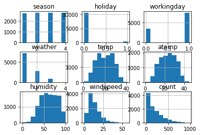

```python
# Create a histogram of all features to show the distribution of each one relative to the data. This is part of the exploritory data analysis
from matplotlib.pylab import plt
fig = plt.figure()
train.hist()
plt.savefig('img/training_raw_histogram.png', dpi=300, bbox_inches='tight')
plt.show()
```

```python
# create a new feature
train['year'] = train.datetime.dt.year
train['month'] = train.datetime.dt.month
train['day'] = train.datetime.dt.day
train['hour'] = train.datetime.dt.hour

test['year'] = test.datetime.dt.year
test['month'] = test.datetime.dt.month
test['day'] = test.datetime.dt.day
test['hour'] = test.datetime.dt.hour
```

## Make category types for these so models know they are not just numbers

- AutoGluon originally sees these as ints, but in reality they are int representations of a category.
- Setting the dtype to category will classify these as categories in AutoGluon.

```python
train["season"]  = train["season"].astype('category')
train["weather"] =  train["weather"].astype('category')
test["season"]   =  test["season"].astype('category')
test["weather"]  =  test["weather"].astype('category')
```

```python
# View are new feature
train.head()
```

|  | datetime | season | holiday | workingday | weather | temp | atemp | humidity | windspeed | count | year | month | day | hour |
| --- | --- | --- | --- | --- | --- | --- | --- | --- | --- | --- | --- | --- | --- | --- |
| 0 | 2011-01-01 00:00:00 | 1 | 0 | 0 | 1 | 9.84 | 14.395 | 81 | 0.0 | 16 | 2011 | 1 | 1 | 0 |
| 1 | 2011-01-01 01:00:00 | 1 | 0 | 0 | 1 | 9.02 | 13.635 | 80 | 0.0 | 40 | 2011 | 1 | 1 | 1 |
| 2 | 2011-01-01 02:00:00 | 1 | 0 | 0 | 1 | 9.02 | 13.635 | 80 | 0.0 | 32 | 2011 | 1 | 1 | 2 |
| 3 | 2011-01-01 03:00:00 | 1 | 0 | 0 | 1 | 9.84 | 14.395 | 75 | 0.0 | 13 | 2011 | 1 | 1 | 3 |
| 4 | 2011-01-01 04:00:00 | 1 | 0 | 0 | 1 | 9.84 | 14.395 | 75 | 0.0 | 1 | 2011 | 1 | 1 | 4 |

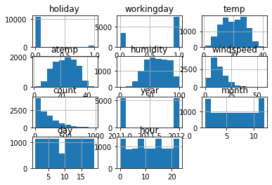

```python
# View histogram of all features again now with the hour feature
from matplotlib.pylab import plt
fig = plt.figure()
train.hist()
plt.savefig('img/training_feat_add_histogram.png', dpi=300, bbox_inches='tight')
plt.show()
```

## Step 5: Rerun the model with the same settings as before, just with more features

```python
train = train.drop('datetime',axis=1)
test  = test.drop('datetime',axis=1)
train = train.drop('year',axis=1)
test  = test.drop('year',axis=1)
```

```python
# predictor_new_features = TabularPredictor(?).fit(?)
predictor_new_features = TabularPredictor(label="count",eval_metric = 'root_mean_squared_error',problem_type="regression").fit(
    train_data=train, time_limit=600, presets="best_quality"
)
```

```
No path specified. Models will be saved in: "AutogluonModels/ag-20220902_024654/"
Presets specified: ['best_quality']
Beginning AutoGluon training ... Time limit = 600s
AutoGluon will save models to "AutogluonModels/ag-20220902_024654/"
AutoGluon Version:  0.3.1
Train Data Rows:    10886
Train Data Columns: 11
Preprocessing data ...
Using Feature Generators to preprocess the data ...
Fitting AutoMLPipelineFeatureGenerator...
	Available Memory:                    2114.46 MB
	Train Data (Original)  Memory Usage: 0.81 MB (0.0% of available memory)
	Inferring data type of each feature based on column values. Set feature_metadata_in to manually specify special dtypes of the features.
	Stage 1 Generators:
		Fitting AsTypeFeatureGenerator...
			Note: Converting 2 features to boolean dtype as they only contain 2 unique values.
	Stage 2 Generators:
		Fitting FillNaFeatureGenerator...
	Stage 3 Generators:
		Fitting IdentityFeatureGenerator...
		Fitting CategoryFeatureGenerator...
			Fitting CategoryMemoryMinimizeFeatureGenerator...
	Stage 4 Generators:
		Fitting DropUniqueFeatureGenerator...
	Types of features in original data (raw dtype, special dtypes):
		('category', []) : 2 | ['season', 'weather']
		('float', [])    : 3 | ['temp', 'atemp', 'windspeed']
		('int', [])      : 6 | ['holiday', 'workingday', 'humidity', 'month', 'day', ...]
	Types of features in processed data (raw dtype, special dtypes):
		('category', [])  : 2 | ['season', 'weather']
		('float', [])     : 3 | ['temp', 'atemp', 'windspeed']
		('int', [])       : 4 | ['humidity', 'month', 'day', 'hour']
		('int', ['bool']) : 2 | ['holiday', 'workingday']
	0.1s = Fit runtime
	11 features in original data used to generate 11 features in processed data.
	Train Data (Processed) Memory Usage: 0.65 MB (0.0% of available memory)
Data preprocessing and feature engineering runtime = 0.14s ...
AutoGluon will gauge predictive performance using evaluation metric: 'root_mean_squared_error'
	To change this, specify the eval_metric argument of fit()
AutoGluon will fit 2 stack levels (L1 to L2) ...
Fitting 11 L1 models ...
Fitting model: KNeighborsUnif_BAG_L1 ... Training model for up to 399.81s of the 599.86s of remaining time.
	-123.9216	 = Validation score   (root_mean_squared_error)
	0.03s	 = Training   runtime
	0.2s	 = Validation runtime
Fitting model: KNeighborsDist_BAG_L1 ... Training model for up to 399.33s of the 599.38s of remaining time.
	-119.3726	 = Validation score   (root_mean_squared_error)
	0.03s	 = Training   runtime
	0.21s	 = Validation runtime
Fitting model: LightGBMXT_BAG_L1 ... Training model for up to 398.84s of the 598.89s of remaining time.
```

[output not shown]

[output not shown]

[output not shown]

[output not shown]

[output not shown]

[output not shown]

[output not shown]

[output not shown]

[output not shown]

[output not shown]

```
	-52.365	 = Validation score   (root_mean_squared_error)
	140.38s	 = Training   runtime
	13.15s	 = Validation runtime
Fitting model: LightGBM_BAG_L1 ... Training model for up to 226.79s of the 426.84s of remaining time.
```

```
[1000]	train_set's rmse: 33.3592	valid_set's rmse: 52.5918
[2000]	train_set's rmse: 23.759	valid_set's rmse: 50.5573
[3000]	train_set's rmse: 18.5382	valid_set's rmse: 50.0138
[4000]	train_set's rmse: 15.0877	valid_set's rmse: 49.9663
```

```
[1000]	train_set's rmse: 33.0751	valid_set's rmse: 54.5715
[2000]	train_set's rmse: 23.9171	valid_set's rmse: 52.2193
[3000]	train_set's rmse: 18.9315	valid_set's rmse: 51.3141
[4000]	train_set's rmse: 15.467	valid_set's rmse: 50.8911
[5000]	train_set's rmse: 12.7863	valid_set's rmse: 50.818
[6000]	train_set's rmse: 10.8191	valid_set's rmse: 50.8082
```

```
[1000]	train_set's rmse: 33.3105	valid_set's rmse: 53.1549
[2000]	train_set's rmse: 24.2697	valid_set's rmse: 51.2275
[3000]	train_set's rmse: 19.401	valid_set's rmse: 50.4764
[4000]	train_set's rmse: 15.7236	valid_set's rmse: 50.3236
[5000]	train_set's rmse: 12.8988	valid_set's rmse: 50.3997
```

```
[1000]	train_set's rmse: 32.5463	valid_set's rmse: 60.1829
[2000]	train_set's rmse: 23.4948	valid_set's rmse: 57.9184
[3000]	train_set's rmse: 18.2966	valid_set's rmse: 57.4338
[4000]	train_set's rmse: 14.9832	valid_set's rmse: 56.9543
[5000]	train_set's rmse: 12.5574	valid_set's rmse: 56.8715
[6000]	train_set's rmse: 10.6433	valid_set's rmse: 56.7687
[7000]	train_set's rmse: 9.22102	valid_set's rmse: 56.6909
[8000]	train_set's rmse: 7.96365	valid_set's rmse: 56.6698
[9000]	train_set's rmse: 6.94366	valid_set's rmse: 56.7068
```

```
[1000]	train_set's rmse: 33.4723	valid_set's rmse: 53.5351
[2000]	train_set's rmse: 24.2422	valid_set's rmse: 51.9254
[3000]	train_set's rmse: 19.1923	valid_set's rmse: 51.4401
[4000]	train_set's rmse: 15.6558	valid_set's rmse: 51.1402
[5000]	train_set's rmse: 13.0853	valid_set's rmse: 50.9956
[6000]	train_set's rmse: 11.1529	valid_set's rmse: 51.017
```

```
[1000]	train_set's rmse: 33.0582	valid_set's rmse: 59.0037
[2000]	train_set's rmse: 23.9462	valid_set's rmse: 57.1527
[3000]	train_set's rmse: 18.8212	valid_set's rmse: 56.5909
[4000]	train_set's rmse: 15.3654	valid_set's rmse: 56.1695
```

```
[1000]	train_set's rmse: 33.1019	valid_set's rmse: 56.3277
[2000]	train_set's rmse: 23.8424	valid_set's rmse: 54.9066
[3000]	train_set's rmse: 18.9649	valid_set's rmse: 54.7537
[4000]	train_set's rmse: 15.2679	valid_set's rmse: 54.8261
```

```
[1000]	train_set's rmse: 32.796	valid_set's rmse: 54.6661
[2000]	train_set's rmse: 24.2556	valid_set's rmse: 52.5589
[3000]	train_set's rmse: 18.9353	valid_set's rmse: 51.6378
[4000]	train_set's rmse: 15.4278	valid_set's rmse: 51.3156
[5000]	train_set's rmse: 12.848	valid_set's rmse: 51.1867
[6000]	train_set's rmse: 10.8293	valid_set's rmse: 50.9674
[7000]	train_set's rmse: 9.3828	valid_set's rmse: 50.8947
[8000]	train_set's rmse: 8.20521	valid_set's rmse: 50.8313
[9000]	train_set's rmse: 7.13663	valid_set's rmse: 50.8067
[10000]	train_set's rmse: 6.31845	valid_set's rmse: 50.8541
```

```
[1000]	train_set's rmse: 32.9084	valid_set's rmse: 56.8177
[2000]	train_set's rmse: 24.0182	valid_set's rmse: 54.7819
[3000]	train_set's rmse: 18.7338	valid_set's rmse: 54.2036
[4000]	train_set's rmse: 15.1193	valid_set's rmse: 54.033
```

```
[1000]	train_set's rmse: 33.094	valid_set's rmse: 51.5444
[2000]	train_set's rmse: 24.2495	valid_set's rmse: 49.9577
[3000]	train_set's rmse: 19.1972	valid_set's rmse: 49.5193
```

[output not shown]

[output cut: 129 more lines]

```
	Ran out of time, stopping training early. (Stopping on epoch 9)
	-90.4862	 = Validation score   (root_mean_squared_error)
	75.97s	 = Training   runtime
	2.3s	 = Validation runtime
Fitting model: LightGBMLarge_BAG_L2 ... Training model for up to 2.92s of the 2.9s of remaining time.
	Ran out of time, early stopping on iteration 8. Best iteration is:
	[8]	train_set's rmse: 144.803	valid_set's rmse: 141.853
	Time limit exceeded... Skipping LightGBMLarge_BAG_L2.
Completed 1/20 k-fold bagging repeats ...
Fitting model: WeightedEnsemble_L3 ... Training model for up to 360.0s of the 2.52s of remaining time.
	-49.5607	 = Validation score   (root_mean_squared_error)
	0.45s	 = Training   runtime
	0.0s	 = Validation runtime
AutoGluon training complete, total runtime = 598.15s ...
TabularPredictor saved. To load, use: predictor = TabularPredictor.load("AutogluonModels/ag-20220902_024654/")
```

```python
performance2 = predictor_new_features.evaluate(train)
```

```
Evaluation: root_mean_squared_error on test data: -21.638192118535994
	Note: Scores are always higher_is_better. This metric score can be multiplied by -1 to get the metric value.
Evaluations on test data:
{
    "root_mean_squared_error": -21.638192118535994,
    "mean_squared_error": -468.2113581586732,
    "mean_absolute_error": -13.134814871796435,
    "r2": 0.9857297441945854,
    "pearsonr": 0.9928626120786717,
    "median_absolute_error": -7.340553283691406
}
```

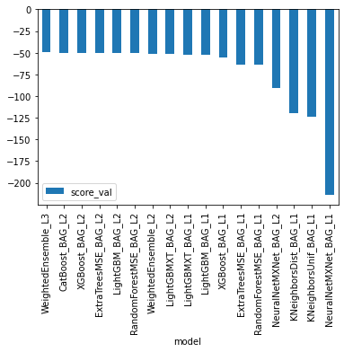

```python
from matplotlib.pylab import plt
fig = plt.figure()
predictor_new_features.leaderboard(silent=True).plot(kind="bar", x="model", y="score_val")

plt.savefig('img/add_feat_training_scores.png', dpi=300, bbox_inches='tight')
plt.show()
```

```python
predictor_new_features.fit_summary()
```

```
*** Summary of fit() ***
Estimated performance of each model:
                     model   score_val  pred_time_val    fit_time  pred_time_val_marginal  fit_time_marginal  stack_level  can_infer  fit_order
0      WeightedEnsemble_L3  -49.560736      21.738622  402.446442                0.000796           0.445053            3       True         17
1          CatBoost_BAG_L2  -49.881721      20.649345  357.145332                0.059106          46.491513            2       True         13
2           XGBoost_BAG_L2  -50.201696      20.714178  323.317353                0.123939          12.663534            2       True         15
3     ExtraTreesMSE_BAG_L2  -50.279929      21.061465  317.411178                0.471225           6.757360            2       True         14
4          LightGBM_BAG_L2  -50.466693      20.710285  317.921917                0.120046           7.268099            2       True         11
5   RandomForestMSE_BAG_L2  -50.527954      21.083556  336.088982                0.493316          25.435163            2       True         12
6      WeightedEnsemble_L2  -50.922215      17.525343  260.863840                0.000933           0.536656            2       True          9
7        LightGBMXT_BAG_L2  -51.250602      20.828454  321.012651                0.238214          10.358833            2       True         10
8        LightGBMXT_BAG_L1  -52.364969      13.153829  140.381296               13.153829         140.381296            1       True          3
9          LightGBM_BAG_L1  -52.421304       3.499470   73.561614                3.499470          73.561614            1       True          4
10          XGBoost_BAG_L1  -55.190919       0.442459   38.535540                0.442459          38.535540            1       True          7
11    ExtraTreesMSE_BAG_L1  -63.973841       0.427633    3.841290                0.427633           3.841290            1       True          6
12  RandomForestMSE_BAG_L1  -64.150084       0.428652    7.848734                0.428652           7.848734            1       True          5
13   NeuralNetMXNet_BAG_L2  -90.486246      22.888888  386.624565                2.298648          75.970746            2       True         16
14   KNeighborsDist_BAG_L1 -119.372602       0.205159    0.032927                0.205159           0.032927            1       True          2
15   KNeighborsUnif_BAG_L1 -123.921631       0.203203    0.027956                0.203203           0.027956            1       True          1
16   NeuralNetMXNet_BAG_L1 -214.282676       2.229835   46.424462                2.229835          46.424462            1       True          8
Number of models trained: 17
Types of models trained:
{'StackerEnsembleModel_LGB', 'StackerEnsembleModel_XGBoost', 'StackerEnsembleModel_RF', 'StackerEnsembleModel_CatBoost', 'StackerEnsembleModel_XT', 'WeightedEnsembleModel', 'StackerEnsembleModel_KNN', 'StackerEnsembleModel_TabularNeuralNet'}
Bagging used: True  (with 10 folds)
Multi-layer stack-ensembling used: True  (with 3 levels)
Feature Metadata (Processed):
(raw dtype, special dtypes):
('category', [])  : 2 | ['season', 'weather']
('float', [])     : 3 | ['temp', 'atemp', 'windspeed']
('int', [])       : 4 | ['humidity', 'month', 'day', 'hour']
('int', ['bool']) : 2 | ['holiday', 'workingday']
Plot summary of models saved to file: AutogluonModels/ag-20220902_024654/SummaryOfModels.html
*** End of fit() summary ***
```

[output not shown]

[output cut: 163 more lines]

```
 2          15
 3          14
 4          11
 5          12
 6           9
 7          10
 8           3
 9           4
 10          7
 11          6
 12          5
 13         16
 14          2
 15          1
 16          8  }
```

```python
predictions = predictor_new_features.predict(test)
predictions.head()
```

```
0    26.834600
1     6.421085
2     5.920944
3     4.737945
4     4.356205
Name: count, dtype: float32
```

```python
predictions.describe()
```

```
count    6493.000000
mean      188.945251
std       165.356049
min         3.241826
25%        48.223343
50%       150.480392
75%       275.234680
max       823.491211
Name: count, dtype: float64
```

```python
# Remember to set all negative values to zero
predictions[predictions<0]=0
```

```python
# Same submitting predictions
submission_new_features = pd.read_csv('sampleSubmission.csv',parse_dates=['datetime'])
submission_new_features["count"] = predictions
submission_new_features.to_csv("submission_new_features.csv", index=False)
```

```python
!kaggle competitions submit -c bike-sharing-demand -f submission_new_features.csv -m "new features"
```

```
Successfully submitted to Bike Sharing Demand
```

```python
!kaggle competitions submissions -c bike-sharing-demand | tail -n +1 | head -n 6
```

```
fileName                     date                 description                        status    publicScore  privateScore
---------------------------  -------------------  ---------------------------------  --------  -----------  ------------
submission_new_features.csv  2022-09-02 03:02:08  new features                       complete  0.54208      0.54208
submission.csv               2022-09-02 02:42:14  first raw submission               complete  1.38447      1.38447
submission_new_hpo.csv       2022-08-31 06:55:43  new features with hyperparameters  complete  0.49558      0.49558
submission_new_hpo.csv       2022-08-31 06:42:13  new features with hyperparameters  complete  0.49622      0.49622
```